# One decision, many ontologies: a carriage-road path from Camden to the Snow Bowl

Cory Whitney

05 October 2026

> **Where I am coming from.** I am a Camden resident. I run a non-profit and an LLC in town, and my home is just off Hosmer Pond Road, on Emery Way, on the way to the Snow Bowl. My neighbors and I have discussed this and think a separated path would be a great thing: cycling on the road as it is today is too dangerous, and a safe route could have major benefits. That is my view, and I may be one of the neighbors a path would pass, so I have a personal stake. The model is built to give every group’s view equal space, and its inputs are placeholders, so nothing in it should be read as support for that view.

> **Status: a scaffold with placeholder inputs.** Every input range in the stakeholder tables is a placeholder invented so the pipeline runs, except where a table row says it is cited. The route geometry (length, parcels, climb) is measured from public data. Read the results as the *shape* of the problem, not as evidence.

## 1. The decision

Should a separated carriage-road path be built between downtown Camden and the Camden Snow Bowl, instead of relying on Hosmer Pond Road? Each stakeholder group sees the same physical change (a few hectares of corridor, more trips, some trees) through its own **ontology**: what exists, what causes what, and what counts as good or bad. Each ontology is a causal diagram (DAG), an input table and an outcome function; they are combined in one `decisionSupport` Monte Carlo model.

The Snow Bowl is **not** a separate party. It is a Town-owned special revenue fund run by Parks and Recreation, kept apart from the General Fund (Camden FY2026 municipal budget message). So the Town and the Snow Bowl form one ontology and one player, with two budget pockets.

```r
data.frame(Group = vapply(stakeholders, `[[`, "", "label"),
           `Sees the road as` = vapply(stakeholders, `[[`, "", "ontology"),
           Values = vapply(stakeholders, function(s) nrow(s$values), 1L), check.names = FALSE, row.names = NULL)
```

[output not shown]

## 2. The geography (measured)

Routes are cheapest paths on OpenStreetMap roads and trails (`gis/02_routes.R`); parcels are from the Maine GeoLibrary and elevation from USGS 3DEP (`gis/03_parcels_elevation.R`).

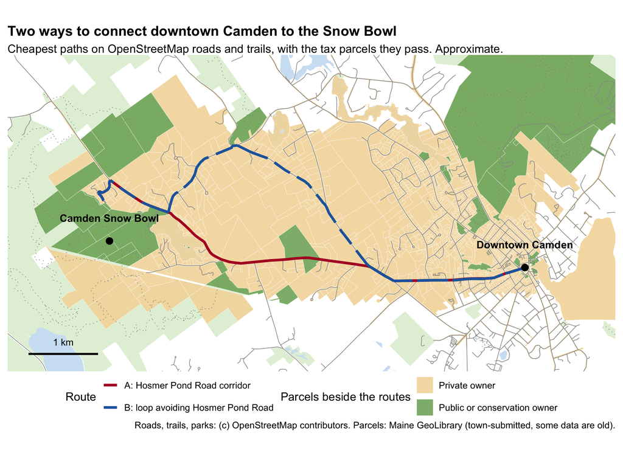

```r
plot_routes_map()
```

```r
rs <- rd("gis/outputs/route_summary.csv"); ps <- rd("gis/outputs/parcel_summary.csv")
merge(rs[, c("route", "length_km", "pct_hosmer_pond_road", "straight_line_km")],
      ps[, c("route", "parcels_touched", "private_parcels_touched", "public_parcels_touched")], by = "route")
```

| route | length_km | pct_hosmer_pond_road | straight_line_km | parcels_touched | private_parcels_touched | public_parcels_touched |
| --- | --- | --- | --- | --- | --- | --- |
| A road corridor (Hosmer Pond Road idea) | 6.91 | 46 | 5.98 | 206 | 197 | 9 |
| B existing trails where possible | 6.92 | 46 | 5.98 | 203 | 194 | 9 |
| C park land where possible | 6.91 | 46 | 5.98 | 206 | 197 | 9 |
| D avoiding Hosmer Pond Road | 7.87 | 0 | 5.98 | 212 | 207 | 5 |

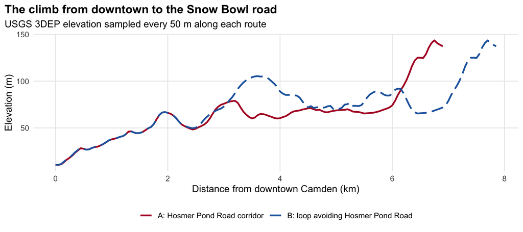

```r
plot_elevation()
```

```r
rd("gis/outputs/grade_summary.csv")
```

| route | start_elev_m | end_elev_m | net_climb_m | total_ascent_m | mean_grade_pct | max_100m_grade_pct | pct_over_8 |
| --- | --- | --- | --- | --- | --- | --- | --- |
| A road corridor (Hosmer Pond Road idea) | 10.65157 | 137.2343 | 127 | 189 | 1.8 | 15.4 | 11 |
| B existing trails where possible | 10.61241 | 137.2343 | 127 | 189 | 1.8 | 15.4 | 11 |
| C park land where possible | 10.65157 | 137.2343 | 127 | 189 | 1.8 | 15.4 | 11 |
| D avoiding Hosmer Pond Road | 10.59241 | 137.2343 | 127 | 229 | 1.6 | 15.4 | 12 |

## 3. Stage 1: what each group gains or loses

The bubble matrix shows, for each group’s own values, the median change against the status quo (blue gain, red loss), sized by magnitude on that value’s own scale and faded by uncertainty about the sign.

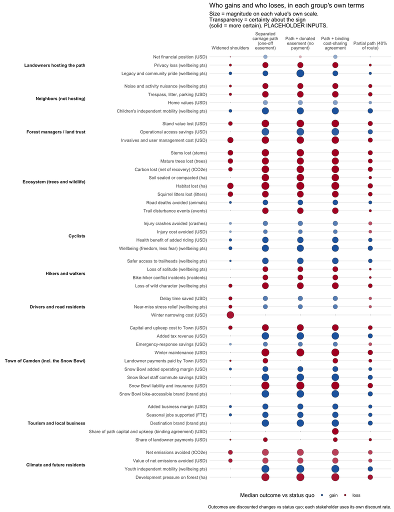

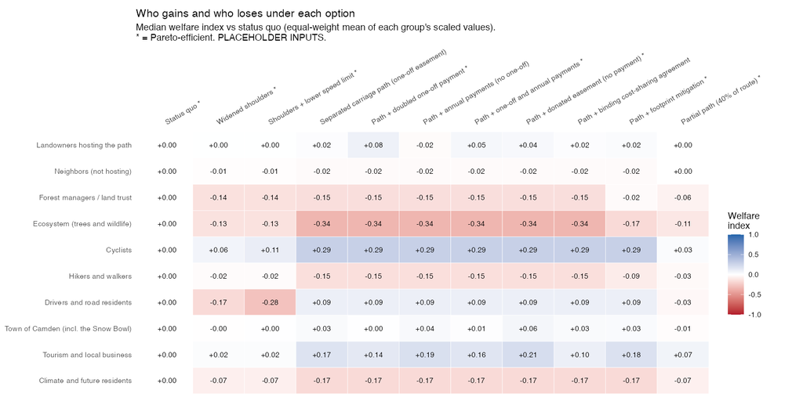

```r
summ <- rd("outputs/liability_protected/value_summary.csv")
bubble_matrix(summ, stakeholders,
              options = c("shoulders", "carriage_path", "path_donated", "path_cost_sharing", "partial_path"),
              title = "Who gains and who loses, in each group's own terms")
```

With the placeholders every option makes some group worse off, so there is no neutral choice: a recommendation is a distributional choice. The all-groups Pareto views are in `outputs/`.

## 4. The Town’s two pockets

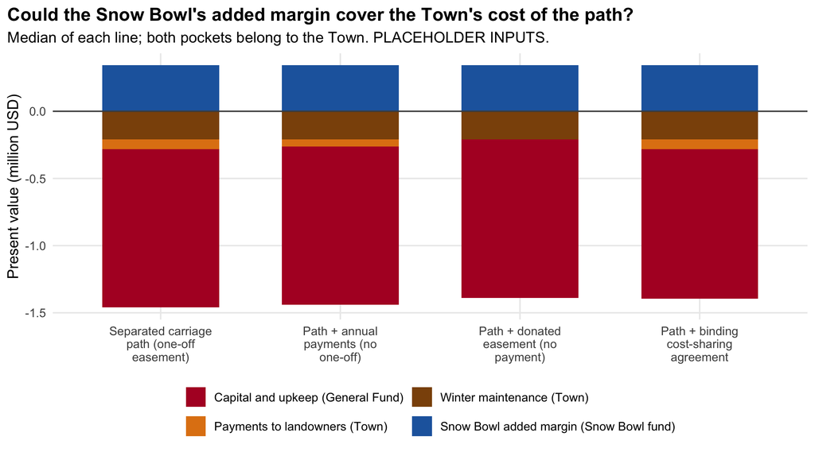

```r
plot_budget_pockets()
```

Because the Snow Bowl fund belongs to the Town, the question is not “who among the Town and the Snow Bowl pays” but whether the margin the path earns in the Snow Bowl fund can be **earmarked** to the path’s cost, and what the General Fund must cover. The Snow Bowl fund itself runs close to break even (FY2026 budget message), so the margin is a new inflow, not a reserve.

## 5. Stage 2: a game of three players

Players: the Town (including the Snow Bowl), landowners (as one collective player) and local business.

```r
pick <- function(f) { o <- rd(f); o$nash_prob <- round(o$nash_prob, 2); o[1:6, c("label", "nash_prob", "nash_at_mean")] }
cat("Voluntary contributions (protected liability scenario)")
```

```
## Voluntary contributions (protected liability scenario)
```

```r
pick("outputs/liability_protected/game_voluntary_outcomes.csv")
```

|  | label | nash_prob | nash_at_mean |
| --- | --- | --- | --- |
| 1 | Status quo (nothing built) | 0.46 | TRUE |
| 2 | Path, donated easement; business free-rides | 0.38 | TRUE |
| 3 | Path, donated easement; business pays | 0.38 | TRUE |
| 4 | Shoulders; business free-rides | 0.14 | FALSE |
| 5 | Path, one-off payment; business free-rides | 0.13 | FALSE |
| 6 | Partial path on public land only (landowners refuse) | 0.10 | FALSE |

```r
cat("Binding cost-sharing agreement")
```

```
## Binding cost-sharing agreement
```

```r
pick("outputs/liability_protected/game_binding_outcomes.csv")
```

|  | label | nash_prob | nash_at_mean |
| --- | --- | --- | --- |
| 1 | Status quo (nothing built) | 0.45 | TRUE |
| 2 | Path, donated easement; binding cost-sharing | 0.39 | TRUE |
| 3 | Shoulders; business free-rides | 0.14 | FALSE |
| 4 | Path, one-off payment; binding cost-sharing | 0.13 | FALSE |
| 5 | Partial path on public land only (landowners refuse); binding cost-sharing | 0.10 | FALSE |
| 6 | Path, annual payments; binding cost-sharing | 0.01 | FALSE |

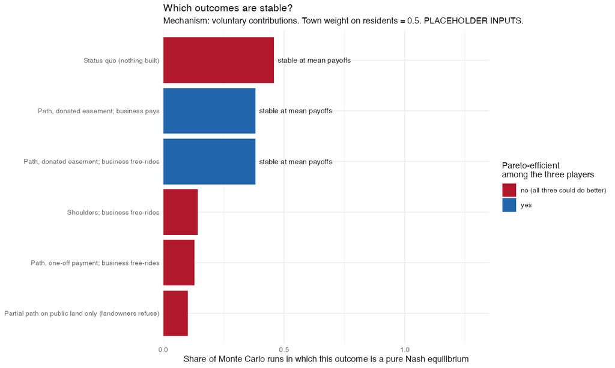

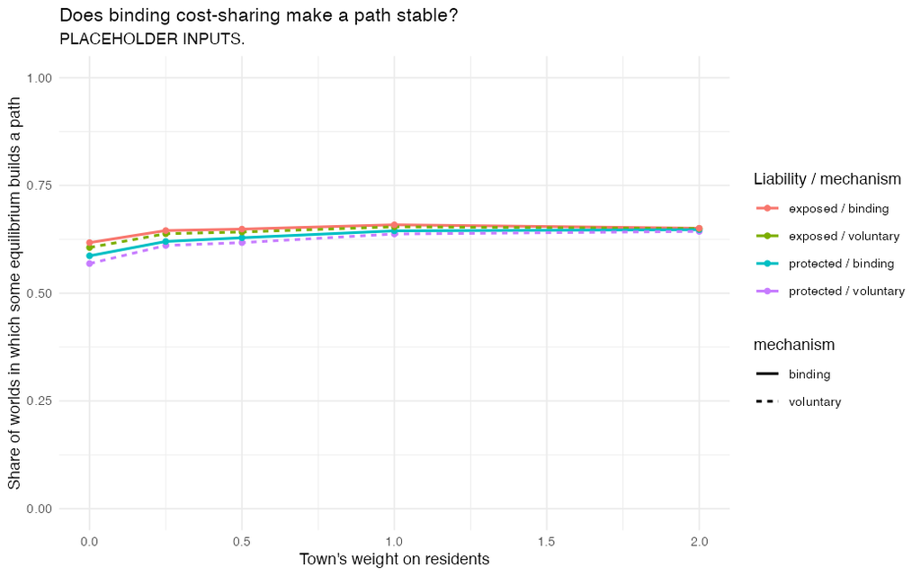

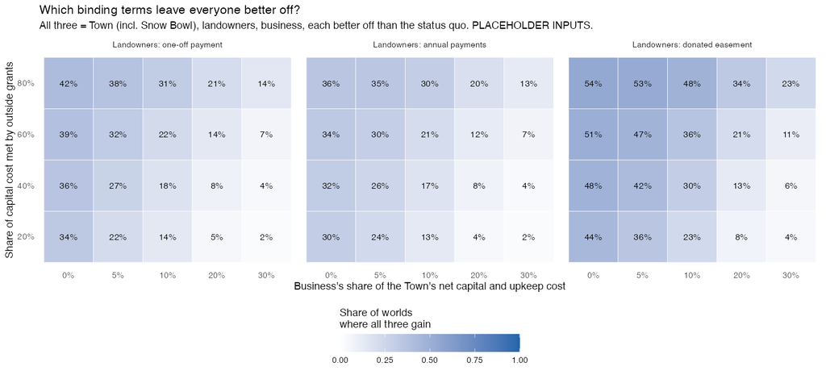

### What changed when the Snow Bowl joined the Town

An earlier version treated the Snow Bowl as a separate player. With the Snow Bowl’s gains counted in the Town’s own payoff, the Town no longer loses from the path at the median, and a path becomes a stable outcome in most simulated worlds. The earlier finding that “the Town is the bottleneck” came from leaving those gains out of its payoff. This is a modelling lesson, not yet a result: the Snow Bowl inputs are placeholders.

## 6. Liability scenarios

Whether paying hosts for an easement counts as “consideration” under Maine’s recreational use statute ([14 MRSA 159-A](https://legislature.maine.gov/statutes/14/title14sec159-A.html)) is a legal question that needs a Maine attorney. Both cases run as scenarios.

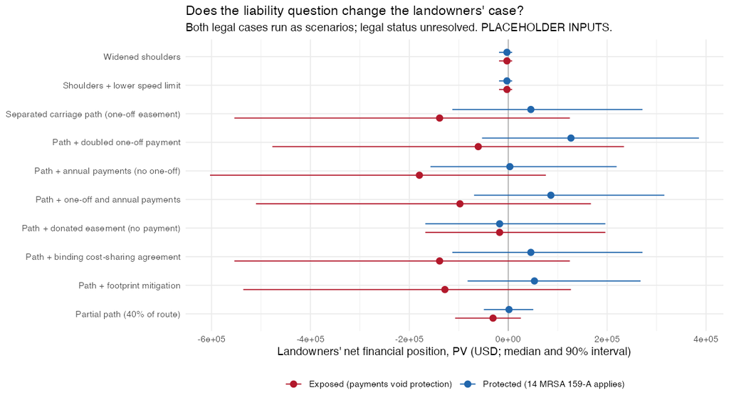

## 7. Where the numbers come from

- **Placeholders:** all ranges unless marked. See `inputs/all_inputs.csv`.
- **Cited:** carbon price range in the NPV Pareto view (Rennert et al. 2022). Methods behind the other exchange rates are cited in `R/exchange_rates.R`; their per-unit numbers remain placeholders.
- **Measured:** route lengths, parcel counts, climb (GIS).
- **Verified fact:** the Snow Bowl is a Town special revenue fund outside the General Fund.

**References** (checked against Crossref, 2026-10-05)

- Rennert, K., Errickson, F., Prest, B. C., Rennels, L., Newell, R. G., Pizer, W. (2022). Comprehensive evidence implies a higher social cost of CO2. *Nature* 610, 687-692. https://doi.org/10.1038/s41586-022-05224-9
- De Neve, J.-E., Clark, A. E., Krekel, C., Layard, R., O’Donnell, G. (2020). Taking a wellbeing years approach to policy choice. *BMJ*, m3853. https://doi.org/10.1136/bmj.m3853
- Costanza, R., de Groot, R., Sutton, P., van der Ploeg, S., Anderson, S. J., Kubiszewski, I. (2014). Changes in the global value of ecosystem services. *Global Environmental Change* 26, 152-158. https://doi.org/10.1016/j.gloenvcha.2014.04.002
- Arrow, K., Cropper, M., Gollier, C., Groom, B., Heal, G., Newell, R. (2013). Determining benefits and costs for future generations. *Science* 341, 349-350. https://doi.org/10.1126/science.1235665
- Drupp, M. A., Freeman, M. C., Groom, B., Nesje, F. (2018). Discounting disentangled. *American Economic Journal: Economic Policy* 10, 109-134. https://doi.org/10.1257/pol.20160240

Map data: (c) OpenStreetMap contributors (ODbL). Parcels: Maine GeoLibrary. Elevation: USGS 3DEP.